# [chad.a.naber|david.r.elfi]@intel.com

[figure not shown]

**This is about our journey in Big Data**

[figure not shown]

**Seemed very loooong journey, but it endeed up been not so long**

## Destinations

- Do we have a problem? Clearly define the question to address
- What type of data? Structured vs semistructured vs unstructured
- How to process all the data? Hadoop!
- Semantic understanding. What does data mean? Work on a data subset
- Implement the model. Is this the best answer?

## Day 0 - Business Question

Journey started with a business focus in:

**Internet of Things**

Question:

> Can we identify if an earthquake is happening based on accelerometer and gyroscope sensors?

## Day 5 - Data

Understanding the data

- Unstructured: No consistent pattern to retrieve specific information
  - General case: language processing
- Semistructured: Part of the data set contains a consistent pattern for retrieving the data required
  - General case: different data formats without a predefined model.
- Structured: Data set contains a well known data model
  - General case: Data import from a legacy system or using a specific standard

```
{
      "timestamp": "2014-02-06T15:03:46.9265437Z",
      "dataTrusted": true,
      "type": "AccelGyro",
      "data": {
         "accel_z": 12305,
         "accel_x": -564,
         "accel_y": -12089,
         "gyro_z": 90,
         "gyro_x": -46,
         "gyro_y": -397
      },
      "sensorAddress": "001208272118"
}
```

## Our data is semistructured: how can we get the schema?

### Schema-on-write

Schema defined previous to write data

### Schema-on-read

Write anything. Schema defined when data is read

## Day 15 - Big Data!

- Using Map/Reduce for Extracting data.
  - Why Big Data? really?

### Our business is Big Data!

## Right Moment to setup Big Data Technology

Loading data and Extracting useful information

# Hadoop

# Spark

# Shark

## Day 30 - Data Preparation

### Data understanding - First Stage

- Data Profiling
  - Nulls/Types identification
  - Maximum
  - Minimum
  - Average
  - Standard Deviation

## Cleaning the data

### Quality Rules

- Remove/transform nulls
- Typefy: precision, UTF8, rounding
- Flag bad data

### Garbage in, Garbage out!

## Day 45 - Visualization

How does data look like?

**Take a representative data subset and play with it**

## Python Framework

- IPython Notebook
- Numpy
- Matplotlib
- scikit-learn and/or Pandas

```
[<mpl_toolkits.mplot3d.art3d.Line3D at 0x45e4e50>]
```

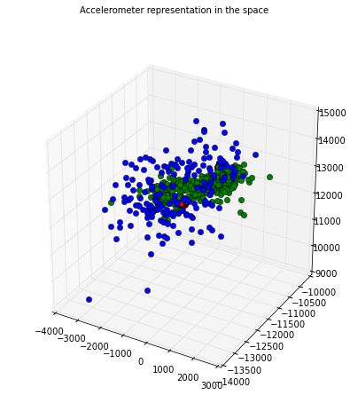

```python
fig = plt.figure(figsize=(7,7))
fig.suptitle("Accelerometer representation in the space")
ax = fig.gca(projection='3d')
ax.plot(accel_x, accel_y, accel_z, "or")
ax.plot(accel_x_eq, accel_y_eq, accel_z_eq, "og")
ax.plot(accel_x_move, accel_y_move, accel_z_move, "ob")
```

## Any conclusion?

## Feature identification

Key for data analysis: *identify which are the values representing the problem*

> Calculate the euclidean distance for each point against the previous one.

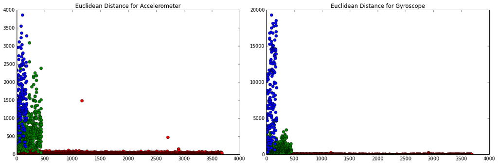

```python
fig,((ax1,ax2)) = plt.subplots(ncols=2, nrows=1, figsize=(15,5))
ax1.plot(eu_dist_accel_rest, "ro")
ax1.plot(eu_dist_accel_eq, "go")
ax1.plot(eu_dist_accel_move, "bo")
ax1.set_title("Euclidean Distance for Accelerometer")
ax2.plot(eu_dist_gyro_rest, "ro")
ax2.plot(eu_dist_gyro_eq, "go")
ax2.plot(eu_dist_gyro_move, "bo")
ax2.set_title("Euclidean Distance for Gyroscope")
plt.tight_layout()
```

## Solving our problem: Pattern identification

### Machine Learning

Supervised:

- Classification methods: Decision Trees, Bayesian
- Regression methods: Linear, Logical
- Neural Networks

Unsupervised:

- Clustering

### Takes time to understand. Look for experts!

### Experts = Data Scientists

## Day 70 - Development

### Purpose

- Train the model with historic data
- Apply the model over historic data

## Example Models

- Linear Regression model ([ref](http://en.wikipedia.org/wiki/Regression_analysis)):

```python
from IPython.display import Math
Math(r'y_i = \beta_0 + \beta_1 x_{i1} + \beta_2 x_{i2} + ... + \beta_p x_{ip} + \varepsilon_i, i = 1, 2, ..., n')
```

$$y_i = \beta_0 + \beta_1 x_{i1} + \beta_2 x_{i2} + ... + \beta_p x_{ip} + \varepsilon_i, i = 1, 2, ..., n$$

- Classification using Graphs
- Decision Trees

## Design approach

Java - Quick ramp up, but bad support for data management

Scala - Great data management support, but not so performant (though is the first language for Spark)

Python using Hadoop streaming - Best in data management, but limited functionality with Hadoop

## Day 90!

We did it:

- Defined a problem
- Loaded and identified data format
- Got understanding of the data
- Worked with a Data Scientist
- Implemented the first model

## Have we answered the question?

## Iterate!

... and keep trying.

[figure not shown]

> "I have not failed 999 times. I have simply found 999 ways how not to create a light bulb"